# Juvenile snowshoe hares counts and sizes: exploratory report

#### C. Juvenile weight comparison (male & female snowshoe hares)

**Table 1.** Descriptive statistics (mean, standard deviation, and sample size) for juvenile weight comparison (male & female snowshoe hares). Data: Kielland et al. (2017)

| Sex | Mean(g) | Median (g) | Standard deviation (g) | Sample size |
| --- | --- | --- | --- | --- |
| Female | 855.39 | 825 | 292.25 | 200 |
| Male | 945.86 | 990 | 333.22 | 163 |
| Missing | 614.55 | 650 | 357.59 | 15 |

#### D. Relationship between juvenile weight & hind foot length.

As a starting point, the relationship between juvenile weight & hind foot length was explored among all snowshoe hares in all sites (Bonanza Black Spruce, Bonanza Mature, and Bonanza Riparian sites);further analysis is needed to compare the relationship between juvenile weight & hind foot length.

The relationship between hind foot length and weight is slightly linear, among juvenile snowshoe hare but not quiet. Simple linear regression revealed that hind foot length is statistically significant in predicting weight among juvenile snowshoe hare (p < 0.001, R<sup>2</sup> = 0.3) with an average slope of $\beta$ = 9.52 g mm<sup>-1</sup> (i.e., for each one millimeter increase in hind foot length we would expect an average increase in snowshoe weight of 9.52 g). Hind foot length and weight are moderately positively correlated (Pearson’s *r* = 0.55, p < 0.001).Diagnostic plots revealed non-linear distribution of residuals (not normally distributed) and heteroscedasticity.Fitted values increase, and the variance of the residuals also increase.Ordinary least squares (OLS) regression assumes that all residuals are drawn from a population that has a constant variance (homoscedasticity) however in these samples it’s not the case.

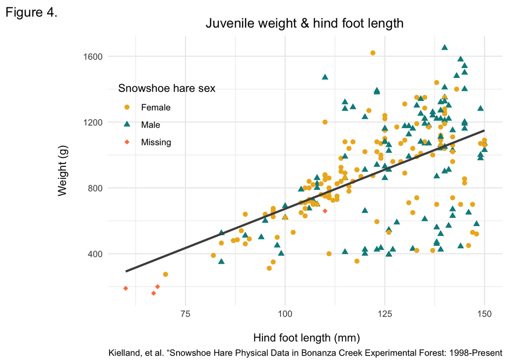

### 4. Summary

- Annual juvenile hare trappings decreased from 1998 to 2012 (Kielland, et al.(2017).
- On average, male juvenile hares weigh more than female juvenile hares at each site (Bonanza Black Spruce, Bonanza Mature, and Bonanza Riparian sites).
- The most juvenile hare trappings occurred at the Bonanza Riparian site.
- There is a moderate positive correlation between juvenile hare hind foot length and weight.
- In order to improve this model, we would need to take into account more variables that could explain the model better. A multiple regression analysis in this case is recommended.

## Citations

Kielland, et al. “Snowshoe Hare Physical Data in Bonanza Creek Experimental Forest: 1999-Present.” Data Portal - Data Package Summary | Environmental Data Initiative (EDI), Environmental Data Initiative, 28 Dec. 2017, https://portal.edirepository.org/nis/mapbrowse?packageid=knb-lter-bnz.55.22.